# R Notebook for Pease Replication 2015 PID

Kat White, Kim Spahr, Andrew Huebert

# Install packages

```r
#install.packages("GGally")
```

# Load libraries

```r
library("tidyverse")
library("haven")
library(olsrr)
library(descriptr)
library(modelr)
library(tidyverse)
library(mosaic)
library(GGally)
```

# Read in the original datafiles

```r
# to print this chunk, but not execute it again once the files are imported, add: eval=FALSE


# use the haven package to read in the data -- we need the MIDUS II data and the biomarker project data
midus2 <- read_spss("04652-0001-Data.sav")
bio <- read_spss("29282-0001-Data.sav")

saveRDS(midus2, "midus2.rds")
saveRDS(bio, "bio.rds")
```

# Read in the saved datafiles

```r
midus2 <- readRDS("midus2.rds")
bio <- readRDS("bio.rds")
```

# Subset the datafiles

```r
midus2.subset <- midus2 %>%
  filter(SAMPLMAJ==1) %>%
  select(M2ID, B1PRSEX, B1PF7A, contains("B1SE6"), B1PAGE_M2, B1SE7I, B1SE7T, B1SE7BB, B1SE7EE, B1SNEURO, B1SEXTRA,B1SOPEN, B1SCONS2, B1SAGREE, B1SMPQAG) %>%
  filter(complete.cases(B1SNEURO, B1SEXTRA, B1SOPEN, B1SCONS2, B1SAGREE, B1SMPQAG, B1PRSEX, B1PAGE_M2, B1PF7A)) %>%
  mutate(IN_MIDUS2<-1)
```

# Change Bio dataframe

```r
bio.subset <- bio %>%
  select(M2ID, contains("B4Q4"), contains("B4Q5"), contains("B4Q6"), B4QTA_AG, B4QTA_AT, B4QTA_AR, B4QAE_AI, B4QAE_AO, B4QAE_AC) %>%
  filter(complete.cases(B4QTA_AG, B4QTA_AT, B4QTA_AR, B4QAE_AI, B4QAE_AO, B4QAE_AC)) %>%
  mutate(IN_BIO<-1)
```

# Combine New Dataframes

```r
combine <- left_join(midus2.subset, bio.subset) %>%
  select(M2ID, B1PF7A, B1SNEURO, B1SAGREE, B1SEXTRA, B1SOPEN, B1SCONS2, B4QTA_AG, B4QTA_AT, B4QTA_AR, B4QAE_AI, B4QAE_AO, B4QAE_AC, B1SMPQAG, B1PF7A, B1PAGE_M2, B1PRSEX, everything())
```

# create dataset for analysis

```r
# note which variables are categorical and numeric and tidy things up
analyze <- combine
all.vars <- names(analyze)
cat.vars <- c("M2ID", "B1PF7A")
analyze <- analyze %>%
  mutate_at(vars(all.vars), funs(as.numeric)) %>%
  mutate_at(vars(cat.vars), funs(as.factor)) %>%
  mutate(GENDER = factor(B1PRSEX, levels = c("1", "2"), labels = c("male", "female"))) %>%
  mutate(MALE = B1PRSEX - 1) %>%
  select(-B1PRSEX)
# create subset of just variable scale scores and the demographic variables
analyze <- analyze %>%
  select(B1SNEURO, B1SAGREE, B1SEXTRA, B1SOPEN, B1SCONS2,
         B4QTA_AG, B4QTA_AT, B4QTA_AR, B4QAE_AI, B4QAE_AO, B4QAE_AC,
         B1SMPQAG,
         B1PF7A,
         B1PAGE_M2,
         GENDER, MALE)
```

# Explore simple linear regression and correlation

## Create a correlation matrix of aggresssion and the Big 5

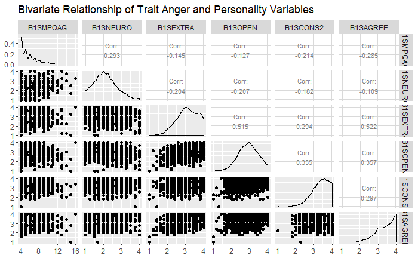

```r
# Our personaility trait is Anger Expression-In (B4QAE_AI)
scatterplot <- ggpairs(analyze,
                       columns = c("B1SMPQAG", "B1SNEURO", "B1SEXTRA", "B1SOPEN", "B1SCONS2", "B1SAGREE"),
                       upper = list(continuous = wrap("cor", size=3)),
        title = "Bivariate Relationship of Trait Anger and Personality Variables")
print(scatterplot, progress=FALSE )
```

## Hone in on Neuroticism and Anger Expression

```r
myvars <- analyze %>%
  select(B1SNEURO, B4QAE_AI) %>%
  na.omit()
```

## Descriptive Statistics

### Anger Expression

```r
summary_stats(myvars$B4QAE_AI)
```

```
                         Univariate Analysis

 N                       627.00      Variance                 16.52
 Missing                   0.00      Std Deviation             4.06
 Mean                     14.72      Range                    23.00
 Median                   14.00      Interquartile Range       5.00
 Mode                     14.00      Uncorrected SS       146265.03
 Trimmed Mean             14.49      Corrected SS          10341.13
 Skewness                  0.87      Coeff Variation          27.60
 Kurtosis                  1.04      Std Error Mean            0.16

                               Quantiles

              Quantile                              Value

             Max                                    31.00
             99%                                    27.00
             95%                                    20.00
             90%                                    22.00
             Q3                                     17.00
             Median                                 14.00
             Q1                                     12.00
             10%                                    10.00
             5%                                     9.00
             1%                                     8.00
             Min                                    8.00

                             Extreme Values

                 Low                                High

  Obs                         Value       Obs                         Value
  18                            8         173                          31
  30                            8         509                          30
  52                            8         564                          30
  103                           8         31                           28
  193                           8         200                          28
```

### Neuroticism

```r
summary_stats(myvars$B1SNEURO)
```

```
                        Univariate Analysis

 N                      627.00      Variance                 0.40
 Missing                  0.00      Std Deviation            0.63
 Mean                     2.05      Range                    3.00
 Median                   2.00      Interquartile Range      1.00
 Mode                     1.75      Uncorrected SS        2884.03
 Trimmed Mean             2.03      Corrected SS           251.86
 Skewness                 0.50      Coeff Variation         30.96
 Kurtosis                -0.06      Std Error Mean           0.03

                              Quantiles

              Quantile                            Value

             Max                                   4.00
             99%                                   3.75
             95%                                   3.00
             90%                                   3.25
             Q3                                    2.50
             Median                                2.00
             Q1                                    1.50
             10%                                   1.25
             5%                                    1.00
             1%                                    1.00
             Min                                   1.00

                            Extreme Values

                Low                                High

  Obs                        Value       Obs                        Value
  15                           1         173                          4
  28                           1         181                          4
  51                           1         183                          4
  52                           1         452                          4
  54                           1         490                          4
```

## Set hypotheses

We are interested in assessing the relationship between anger expression and neuroticism.

Our H0 is that the regression slope is equal to 0 (B1 = 0) Our HA is that the regression slope is not equal to 0 (B1 /=0)

## Set alpha and obtain the critical value of t

```r
qt(c(.025, .975), df=625)
```

```
[1] -1.963767  1.963767
```

## Center neuroticism at the mean and then fit the SLR

```r
myvars <- myvars %>%
  mutate(B1SNEURO_m = B1SNEURO - mean(B1SNEURO))
my_model <- lm(B4QAE_AI ~ B1SNEURO_m, data = myvars)
ols_regress(my_model)
```

```
                        Model Summary
--------------------------------------------------------------
R                       0.334       RMSE                3.834
R-Squared               0.112       Coef. Var          26.039
Adj. R-Squared          0.110       MSE                14.699
Pred R-Squared          0.105       MAE                 3.003
--------------------------------------------------------------
 RMSE: Root Mean Square Error
 MSE: Mean Square Error
 MAE: Mean Absolute Error

                                ANOVA
----------------------------------------------------------------------
                 Sum of
                Squares         DF    Mean Square      F         Sig.
----------------------------------------------------------------------
Regression     1154.537          1       1154.537    78.548    0.0000
Residual       9186.593        625         14.699
Total         10341.131        626
----------------------------------------------------------------------

                                  Parameter Estimates
----------------------------------------------------------------------------------------
      model      Beta    Std. Error    Std. Beta      t        Sig      lower     upper
----------------------------------------------------------------------------------------
(Intercept)    14.724         0.153                 96.164    0.000    14.423    15.024
 B1SNEURO_m     2.141         0.242        0.334     8.863    0.000     1.667     2.615
----------------------------------------------------------------------------------------
```

The intercept is 14.724, which is the predicted anger expression score for individuals with an average level of neuroticism. The slope is 2.141, which is the expected change in anger expression for one unit increase in neuroticism.

The estimate of the slope divided by the associated SE gives a t* of 2.141/0.242 = 8.863. This suggests that our estimate of the slope is 8.863 SE away from the asserted null hypothesis (which is equal to 0). If the H0 were true, we would expect about 95% of the random samples to produce an estimate of the slope that is within 1.963767 standard errors of 0. Thus, it is highly unlikely that the H0 is true given this estimate of the slope. The p-value is acutally less than .001, which suggests that the probability that we would obtain a t* of this magnitude or larger if the H0 were true. Because of this, we can reject the H0 and conclude that anger expression is related to neuroticism.

Overall, it seems that neuroticism is significantly associated with anger expression, with higher scores of neuroticism being associated with higher scores of anger expression. Based on our model, neuroticism predicts 11.2% of the variance in anger expression. In a SLR, the standardized beta is equal to the correlation, so the correlation between neuroticism and anger expression is .334.

## Calculate predicted scores

```r
pregrid <- data_grid(myvars, B1SNEURO_m = c(-.54, 0, .54))
predict(my_model, pregrid, interval = "confidence", level = .95)
```

```
       fit      lwr      upr
1 13.56745 13.17244 13.96245
2 14.72360 14.42293 15.02428
3 15.87976 15.48475 16.27477
```

```r
predict(my_model, pregrid, interval = "prediction", level = .95)
```

```
       fit      lwr      upr
1 13.56745 6.028268 21.10663
2 14.72360 7.188779 22.25843
3 15.87976 8.340582 23.41894
```

## Scatterplot of Neuroticism and Anger Expression

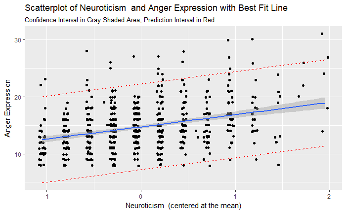

```r
temp_var <- predict(my_model, myvars, interval="prediction")
myvars_new <- cbind(temp_var, myvars)
ggplot(myvars_new, aes(x = B1SNEURO_m, y =B4QAE_AI)) +
  geom_jitter() +
  geom_smooth(method = "lm", se = TRUE) +
  geom_line(aes(y=lwr), color = "red", linetype = "dashed") +
  geom_line(aes(y=upr), color = "red", linetype = "dashed") +
  labs(title = "Scatterplot of Neuroticism  and Anger Expression with Best Fit Line",
       subtitle = "Confidence Interval in Gray Shaded Area, Prediction Interval in Red",
       x = "Neuroticism  (centered at the mean)", y = "Anger Expression")
```

## Create graph of residuals

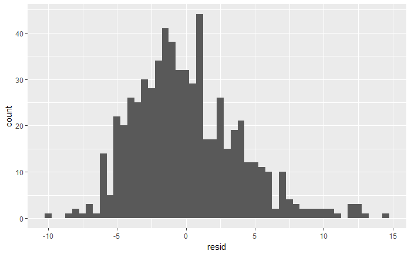

```r
myvars <- myvars %>%
  add_residuals(my_model)
ggplot(myvars, aes(x = resid)) + geom_histogram(binwidth = .5)
```